# Building Models to Predict Pedestrian Traffic Threshold

**Author**: Dahye Kim  
**Document Created**: 21 Jan 2021  
**Last Modified**: 25 Jan 2021

## Libraries used

```python
from pyspark import SparkConf
from pyspark import SparkContext
from pyspark.sql import SparkSession
# establishing Spark session
from pyspark.sql.types import *
# pre-defining data frame schema, changing data type of an attribute
from pyspark.sql.functions import *
# processing dataframe
import builtins
# reimport built-in functions in Python to prevent misusing functions
# from pyspark.sql.functions
import matplotlib.pyplot as plt
# visualisation
import numpy as np
# number arrays
from statistics import mean
# for aggregation
from datetime import date
# converting strings to date and vice versa
import seaborn as sns
# heatmap
import pandas as pd
# pandas dataframe manipulation
import squarify
# treemap
import matplotlib
```

```python
# sc.stop()
```

# 1. Loading the Dataset and Explore the Attributes

## Establishing SparkSession

```python
master = 'local[*]'
# set the processors to use for this project. In this case, all the available processors are called using '*'
app_name = 'Building Models to Predict Pedestrian Traffic'
# the app name for this spark app
spark_conf = SparkConf()\
.setMaster(master)\
.setAppName(app_name)\
.set('spark.sql.session.timeZone', 'UTC')

spark = SparkSession.builder.config(conf=spark_conf).getOrCreate()
sc = spark.sparkContext
sc.setLogLevel('ERROR')
```

## Pre-defining Dataframe Schema

```python
# defining sensor_df schema
sensorSchema = StructType([\
   StructField("sensor_id", IntegerType(), False),\
   StructField("sensor_description", StringType(), False),\
    StructField("sensor_name", StringType(), False),\
    StructField("installation_date", StringType(), False),\
    StructField("status", StringType(), True),\
    StructField("note", StringType(), True),\
    StructField("direction_1", StringType(), False),\
    StructField("direction_2", StringType(), False),\
    StructField("latitude", FloatType(), False),\
    StructField("longitude", FloatType(), False),\
    StructField("location", StringType(), False)
                          ])
```

```python
# defining pedestrian_df schema
pedestrianSchema = StructType([\
   StructField("ID", IntegerType(), False),\
   StructField("Date_Time", StringType(), False),\
    StructField("Year", IntegerType(), False),\
    StructField("Month", StringType(), False),\
    StructField("Mdate", IntegerType(), False),\
    StructField("Day", StringType(), False),\
    StructField("Time", IntegerType(), False),\
    StructField("Sensor_ID", IntegerType(), False),\
    StructField("Sensor_Name", StringType(), False),\
    StructField("Hourly_Counts", IntegerType(), False)
                          ])
```

## Loading CSV Datasets with Pre-defined Schemas

```python
sensor = spark.read.csv('Pedestrian_Counting_System_-_Sensor_Locations.csv',\
                   header = True,\
                   schema = sensorSchema)
# loading the data frame of all the sensors
# keep the header and the schema is predefined above
```

```python
counts = spark.read.csv('Pedestrian_Counting_System_-_Monthly__counts_per_hour.csv',\
                   header = True,\
                   schema = pedestrianSchema)
# loading the data frame of pedestrian counts
# keep the header and the schema is predefined above
```

```python
sensor.printSchema()
# double checking if the schema was implemented
```

```
root
 |-- sensor_id: integer (nullable = true)
 |-- sensor_description: string (nullable = true)
 |-- sensor_name: string (nullable = true)
 |-- installation_date: string (nullable = true)
 |-- status: string (nullable = true)
 |-- note: string (nullable = true)
 |-- direction_1: string (nullable = true)
 |-- direction_2: string (nullable = true)
 |-- latitude: float (nullable = true)
 |-- longitude: float (nullable = true)
 |-- location: string (nullable = true)
```

```python
counts.printSchema()
```

```
root
 |-- ID: integer (nullable = true)
 |-- Date_Time: string (nullable = true)
 |-- Year: integer (nullable = true)
 |-- Month: string (nullable = true)
 |-- Mdate: integer (nullable = true)
 |-- Day: string (nullable = true)
 |-- Time: integer (nullable = true)
 |-- Sensor_ID: integer (nullable = true)
 |-- Sensor_Name: string (nullable = true)
 |-- Hourly_Counts: integer (nullable = true)
```

```python
counts.select([count(when(isnan(eachCol)|col(eachCol).isNull(), eachCol)).alias(eachCol) for eachCol in counts.columns]).show()
# checking null values in the dataframe
```

```
+---+---------+----+-----+-----+---+----+---------+-----------+-------------+
| ID|Date_Time|Year|Month|Mdate|Day|Time|Sensor_ID|Sensor_Name|Hourly_Counts|
+---+---------+----+-----+-----+---+----+---------+-----------+-------------+
|  0|        0|   0|    0|    0|  0|   0|        0|          0|            0|
+---+---------+----+-----+-----+---+----+---------+-----------+-------------+
```

```python
sensor.select([count(when(isnan(eachCol)|col(eachCol).isNull(), eachCol)).alias(eachCol) for eachCol in sensor.columns]).show()
```

```
+---------+------------------+-----------+-----------------+------+----+-----------+-----------+--------+---------+--------+
|sensor_id|sensor_description|sensor_name|installation_date|status|note|direction_1|direction_2|latitude|longitude|location|
+---------+------------------+-----------+-----------------+------+----+-----------+-----------+--------+---------+--------+
|        0|                 0|          0|                0|     0|  64|          4|          4|       0|        0|       0|
+---------+------------------+-----------+-----------------+------+----+-----------+-----------+--------+---------+--------+
```

## Create the Binary Target for Classification: `above_threshold`

```python
counts = counts.withColumn('above_threshold',\
                        when(col('Hourly_Counts') < 2000, 0)\
                        .otherwise(1))
# create a new column 'above_threshold'
# if the values in 'Hourly_Counts' is smaller than 2000, the value for the new column is 0.
# otherwise, 1
```

## Exploring the data

```python
numericalCol = [colName for colName, colType in counts.dtypes \
                if colType != 'string' and colName != 'above_threshold']
# extract the columns with numerical values
```

```python
counts.select(numericalCol).summary().toPandas()
# for a better visualiation, I converted the summary to Pandas dataframe
```

|  | summary | ID | Year | Mdate | Time | Sensor_ID | Hourly_Counts |
| --- | --- | --- | --- | --- | --- | --- | --- |
| 0 | count | 3435106 | 3435106 | 3435106 | 3435106 | 3435106 | 3435106 |
| 1 | mean | 1717553.5 | 2016.0032330880038 | 15.751918863639142 | 11.459955238644746 | 22.978422791028866 | 560.7805942524044 |
| 2 | stddev | 991629.8312350252 | 3.1237869143646275 | 8.79918757461428 | 6.943473866829414 | 16.229792156265397 | 809.9942576353371 |
| 3 | min | 1 | 2009 | 1 | 0 | 1 | 0 |
| 4 | 25% | 858830 | 2014 | 8 | 5 | 9 | 50 |
| 5 | 50% | 1717623 | 2016 | 16 | 11 | 19 | 210 |
| 6 | 75% | 2576510 | 2019 | 23 | 17 | 34 | 722 |
| 7 | max | 3435106 | 2020 | 31 | 23 | 71 | 15979 |

The attribute `Hourly_Counts` is heavily skewed to the right based on the statiscal summary of the attribute.

```python
counts.select('Year', 'Mdate', 'Time', 'Hourly_Counts').toPandas().corr()
```

|  | Year | Mdate | Time | Hourly_Counts |
| --- | --- | --- | --- | --- |
| Year | 1.000000 | -0.000758 | 0.011333 | -0.091666 |
| Mdate | -0.000758 | 1.000000 | 0.000080 | 0.000793 |
| Time | 0.011333 | 0.000080 | 1.000000 | 0.263110 |
| Hourly_Counts | -0.091666 | 0.000793 | 0.263110 | 1.000000 |

Correlation of all numerical attributes shows that `Year` and `Mdate` are indepedent from the `Hourly_Counts`, while `Time` is weakly positively correlated.

## Inspecting Class Imbalance

```python
counts.select('above_threshold')\
.groupBy('above_threshold')\
.count()\
.withColumn('Implication', when(col('above_threshold') == 1, '>= 2000')\
           .otherwise('< 2000')).show()
```

```
+---------------+-------+-----------+
|above_threshold|  count|Implication|
+---------------+-------+-----------+
|              1| 250942|    >= 2000|
|              0|3184164|     < 2000|
+---------------+-------+-----------+
```

## Visualising the Distribution of `Hourly_Counts`

```python
hourlyCounts = list(map(lambda x: x[0], counts.select('Hourly_Counts').collect()))
# use .collect() to retrieve the 'Hourly_Counts' as a list
# use map() to extract the first value of each element in the list
# recreate the mapped values into a list
```

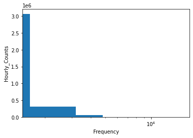

```python
plt.hist(hourlyCounts)
plt.xscale('log')
plt.xlabel('Frequency')
plt.ylabel('Hourly_Counts')
plt.show()
# highly skewed distribution of pedistrian count to the right
# there are more sensors with less counts than with more counts
```

As we already assumed when exploring the statistical summary of the `Hourly_Counts`, the distribution of the attribute is severly skewed to the right. This lead to the heavy class imbalance in `above_threshold`.

## Visualising the Trend of `Hourly_Counts` by Months

```python
# retreive daily count
df = counts.select('Month','Mdate','Hourly_Counts')\
.groupby('Month','Mdate').mean('Hourly_Counts')\
.toPandas()\
.pivot(index = 'Mdate', columns= 'Month')
# select only the columns needed - month, date, and the hourly count of each date
# group by each date and calculate the mean of each group
# convert to Pandas dataframe for visualisation process
# pivot the table with 'Month' as columns for monthly linegraph
```

```python
df.columns = list(map(lambda x: x[1], df.columns))
df = df[['January','February','March',\
        'April','May','June','July','August',\
        'September','October','November','December']]
# rename the columns to proper month names
# reorder the columns based on the proper order
```

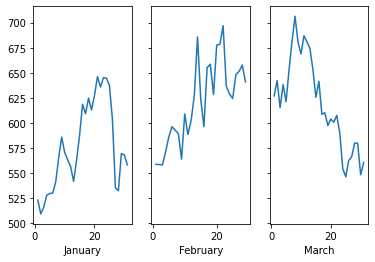

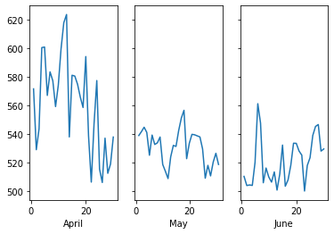

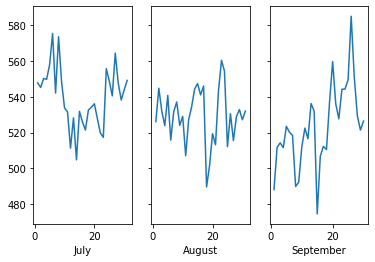

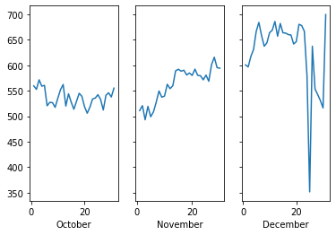

```python
f,a1 = plt.subplots(1, 3, sharey = True)
a1 = a1.ravel()
for idx, ax in enumerate(a1):
    ax.plot([*range(1,df.iloc[:, idx].shape[0]+1)], df.iloc[:, idx])
    ax.set_xlabel(df.columns[idx])

f,a2 = plt.subplots(1, 3, sharey = True)
a2 = a2.ravel()
for idx, ax in enumerate(a2):
    ax.plot([*range(1,df.iloc[:, idx+3].shape[0]+1)], df.iloc[:, idx+3])
    ax.set_xlabel(df.columns[idx+3])

f,a3 = plt.subplots(1, 3, sharey = True)
a3 = a3.ravel()
for idx, ax in enumerate(a3):
    ax.plot([*range(1,df.iloc[:, idx+6].shape[0]+1)], df.iloc[:, idx+6])
    ax.set_xlabel(df.columns[idx+6])

f,a4 = plt.subplots(1, 3, sharey = True)
a4 = a4.ravel()
for idx, ax in enumerate(a4):
    ax.plot([*range(1,df.iloc[:, idx+9].shape[0]+1)], df.iloc[:, idx+9])
    ax.set_xlabel(df.columns[idx+9])
```

## Linegraph of Weekly Average & total Pedestrian Count

```python
dayOfWeek_sum = counts\
.select('Day', 'Time', 'Hourly_Counts')\
.groupBy('Day', 'Time').sum('Hourly_Counts')\
.select(col('sum(Hourly_Counts)').alias('total'),\
       'Day', 'Time')\
.orderBy('Day','Time')
# calculate the total pedestrian count per hour on each weekday
# group by the day of the week and the hour of the day
# sort the dataset for a better line graph representation
```

```python
dayOfWeek = ['Monday', 'Tuesday', 'Wednesday', 'Thursday', 'Friday', 'Saturday', 'Sunday']
hr = [*range(0, 24)]
# set the labels of each line and the x-axis of the line graph
```

```python
dailyTotalCount = []
# the list holds 7 lists, each list with the hourly pedestrain count of a day of a week

for i in dayOfWeek:
    temp_sum = dayOfWeek_sum.filter(col('Day') == i).select('total').collect()
    totalCount_day = list(map(lambda x: x[0], temp_sum))
    # retrieve the rows with only the day of the week in the loop
    # convert the total pedestrian count into an array
    dailyTotalCount.append(totalCount_day)
```

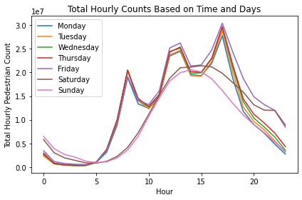

```python
for i in range(0,len(dailyTotalCount)):
# looping through each day of the week
    plt.plot(hr, dailyTotalCount[i], label = dayOfWeek[i])
    plt.legend(loc = 'upper left', prop = {'size':10})
    plt.xlabel('Hour')
    plt.ylabel('Total Hourly Pedestrian Count')
    plt.title('Total Hourly Counts Based on Time and Days')
    plt.tight_layout()
```

Through the line graph above, we could assume a possible influence of the days of the week to the pedestrian count in Melbourne. The weekdays, especially until Friday, the pattern of pedestrian count is unified - pedestrian count hits three peaks during the day, at 8-9am, 12-1pm, and 5-6pm. These hours could be interpreted as rush hour during the morning, lunch hour, and another rush hour timeframe during in the evening. The pattern changes slightly during Fridays, that the pedestrian counts increases slightly at night in comparison to other weekdays. Additionally, the pedestrian count during the mid-night until 5am is much higher on weekend mornings. Surprisingly, the pedestrian count decreases significantly during the weekends with only one peak during the day - at 3pm. However, on Sundays, the pedestrian counts after 3pm is signifcantly lower than that of Saturdays. This could be due to the early business closing time in Melbourne on Sundays.

## Heatmap of Pedestrian Count - Month to Day of Weeks

```python
month_wk = counts\
.select('Month','Day','Hourly_Counts')\
.groupBy('Month','Day')\
.mean('Hourly_Counts')\
.select('Month','Day',\
       col('avg(Hourly_Counts)').alias('mean'))\
.toPandas().pivot(index = 'Day', columns = 'Month')
# to retrieve the average pedestrian count based on the month and the week
# group by month and day of the week
# calculate the average of each group
# convert the dataset to pandas dataframe for visualisation process
# pivot the table, month as column and each row represent each day of the week
month_wk.columns = list(map(lambda x: x[1], month_wk.columns))
month_wk = month_wk[df.columns].reindex(dayOfWeek)
# order the row and the column
```

```python
month_wk0 = counts\
.filter(col('above_threshold') == 0)\
.select('Month','Day','Hourly_Counts')\
.groupBy('Month','Day')\
.mean('Hourly_Counts')\
.select('Month','Day',\
       col('avg(Hourly_Counts)').alias('mean'))\
.toPandas().pivot(index = 'Day', columns = 'Month')
month_wk0.columns = list(map(lambda x: x[1], month_wk0.columns))
month_wk0 = month_wk0[df.columns].reindex(dayOfWeek)
```

```python
month_wk1 = counts\
.filter(col('above_threshold') == 1)\
.select('Month','Day','Hourly_Counts')\
.groupBy('Month','Day')\
.mean('Hourly_Counts')\
.select('Month','Day',\
       col('avg(Hourly_Counts)').alias('mean'))\
.toPandas().pivot(index = 'Day', columns = 'Month')
month_wk1.columns = list(map(lambda x: x[1], month_wk1.columns))
month_wk1 = month_wk1[df.columns].reindex(dayOfWeek)
```

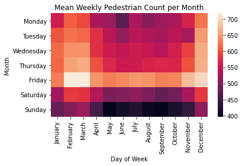

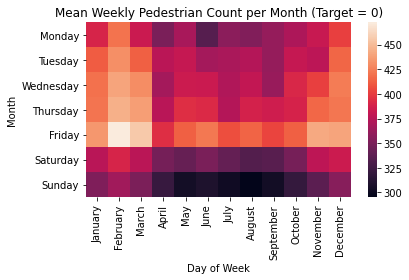

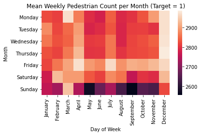

```python
hm1 = plt.figure(1)
hm1 = sns.heatmap(month_wk)
hm1.set_xlabel('Day of Week')
hm1.set_ylabel('Month')
hm1.set_title('Mean Weekly Pedestrian Count per Month')
plt.tight_layout()

hm2 = plt.figure(2)
hm2 = sns.heatmap(month_wk0)
hm2.set_xlabel('Day of Week')
hm2.set_ylabel('Month')
hm2.set_title('Mean Weekly Pedestrian Count per Month (Target = 0)')
plt.tight_layout()

hm3 = plt.figure(3)
hm3 = sns.heatmap(month_wk1)
hm3.set_xlabel('Day of Week')
hm3.set_ylabel('Month')
hm3.set_title('Mean Weekly Pedestrian Count per Month (Target = 1)')
plt.tight_layout()
```

# 2. Feature Extraction and ML Training

In this section, I am using PySpark DataFrame functions and ML packages for data preparation, model building and evaluation.

The features that I am *not* using are as follow:

- **ID**: The attribute is only a primary key for identifying the entry
- **Date_Time**: The elements of this column are already broken down into different columns.
- **Mdate**: The correlation of this feature and the target column is near to 0.
- **Sensor_ID**: There are 72 different sensors and it is computationally expensive to have 72 differnent new attributes just for this categorical feature. However, to signify the difference in pedestrian count by different sensors, I added a new column `SensorCategory` and divided sensor IDs to different levels.
- **Sensor_Name**: Similar to **Sensor_ID**, the attribute is replaced by `SensorCategory`.
- **Month**: Instead of using a categorical feature with 12 different levels, I replaced it using **WarmerMonth**
- **Day**: Instead of using a categorical feature with 7 different levels, I replaced it using **Week**
- **Time**: Replaced it with **Hour** attribute

## `SensorCategory` Attribute

```python
sensor_1 = counts\
.filter(col('above_threshold') == 1)\
.select('Sensor_ID','Hourly_Counts')\
.groupBy('Sensor_ID')\
.mean('Hourly_Counts')\
.select(round(col('avg(Hourly_Counts)'),4).alias('sensor_avg_1'),\
       'Sensor_ID')\
.orderBy('sensor_avg_1').toPandas()
# retrieving total pedestrian count of each sensor

sensor_0 = counts\
.filter(col('above_threshold') == 0)\
.select('Sensor_ID','Hourly_Counts')\
.groupBy('Sensor_ID')\
.mean('Hourly_Counts')\
.select(round(col('avg(Hourly_Counts)'),4).alias('sensor_avg'),\
       col('Sensor_ID')).orderBy('sensor_avg').toPandas()
# retreving average pedestrian count of each sensor
# set alias to Sensor_ID to hamper the ambivalence when joining datasets
```

```
(0.0, 100.0, 0.0, 100.0)
```

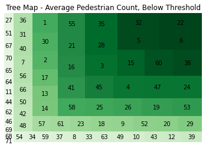

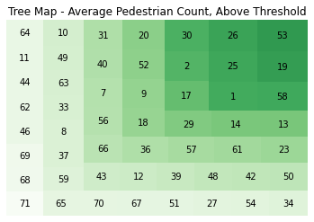

```python
norm = matplotlib.colors.Normalize(vmin=sensor_0['sensor_avg'].min(), \
                                   vmax=sensor_0['sensor_avg'].max())
colors = [matplotlib.cm.Greens(norm(value)) for value in sensor_0['sensor_avg']]
# set the colour schema for treemaps

tree1 = plt.figure(1)
tree1 = squarify.plot(sizes=sensor_0['sensor_avg'], \
              label = sensor_0['Sensor_ID'], \
              color = colors)
tree1.axis('off')
tree1.set_title('Tree Map - Average Pedestrian Count, Below Threshold')

sensor_1.sort_values(by = ['sensor_avg_1'], inplace = True)
tree2 = plt.figure(2)
tree2 = squarify.plot(sizes=sensor_1['sensor_avg_1'], \
              label = sensor_0['Sensor_ID'], \
              color = colors)
tree2.set_title('Tree Map - Average Pedestrian Count, Above Threshold')
tree2.axis('off')
```

1. Aggregating the `counts` dataframe and retrieve the average count of each sensor
2. Using `pd.cut()` function to generate 6 different levels in average pedestrian count
3. Categorise sensors based on each average count levels from 2.

## `Holiday` Attribute

```python
month_day = counts\
.select('Month','Mdate','Hourly_Counts')\
.filter(col('Time').isin([0]+[*range(9,24)]))\
.groupBy('Month','Mdate')\
.mean('Hourly_Counts')\
.select('Month','Mdate',\
       col('avg(Hourly_Counts)').alias('mean'))\
.toPandas()\
.pivot_table(index = 'Month', columns = 'Mdate')\
.reindex(list(df.columns))
# group by month and date
# calculate the average of hourly count of each group
# convert the dataset to pandas dataframe for visualisation
# pivot the table and define the date as columns, month as rows
# sort rows based on month orders
month_day.columns = list(map(lambda x: x[1], month_day.columns))
# rename the columns by the date only
```

```python
month_day0 = counts\
.select('Month','Mdate','Hourly_Counts')\
.filter((col('Time').isin([0]+[*range(9,24)]))&\
       (col('above_threshold') == 0))\
.groupBy('Month','Mdate')\
.mean('Hourly_Counts')\
.select('Month','Mdate',\
       col('avg(Hourly_Counts)').alias('mean'))\
.toPandas()\
.pivot_table(index = 'Month', columns = 'Mdate')\
.reindex(list(df.columns))
month_day0.columns = list(map(lambda x: x[1], month_day0.columns))
```

```python
month_day1 = counts\
.select('Month','Mdate','Hourly_Counts')\
.filter((col('Time').isin([0]+[*range(9,24)]))&\
       (col('above_threshold') == 1))\
.groupBy('Month','Mdate')\
.mean('Hourly_Counts')\
.select('Month','Mdate',\
       col('avg(Hourly_Counts)').alias('mean'))\
.toPandas()\
.pivot_table(index = 'Month', columns = 'Mdate')\
.reindex(list(df.columns))
month_day1.columns = list(map(lambda x: x[1], month_day1.columns))
```

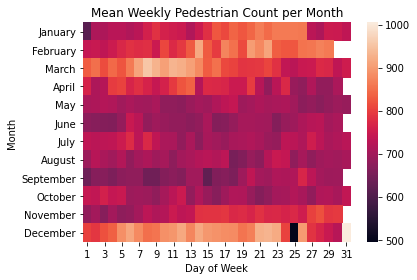

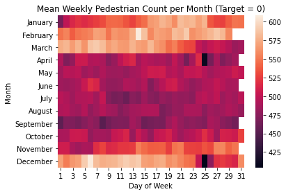

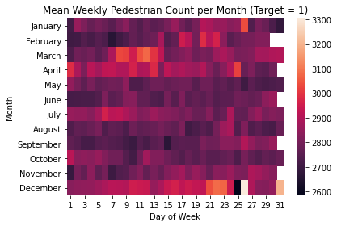

```python
hm1 = plt.figure(1)
hm1 = sns.heatmap(month_day)
hm1.set_xlabel('Day of Week')
hm1.set_ylabel('Month')
hm1.set_title('Mean Weekly Pedestrian Count per Month')
plt.tight_layout()

hm2 = plt.figure(2)
hm2 = sns.heatmap(month_day0)
hm2.set_xlabel('Day of Week')
hm2.set_ylabel('Month')
hm2.set_title('Mean Weekly Pedestrian Count per Month (Target = 0)')
plt.tight_layout()

hm3 = plt.figure(3)
hm3 = sns.heatmap(month_day1)
hm3.set_xlabel('Day of Week')
hm3.set_ylabel('Month')
hm3.set_title('Mean Weekly Pedestrian Count per Month (Target = 1)')
plt.tight_layout()
```

I visualised the linegraph in 1.2.3 for a better grasp of pedestrian count of each day in each month. From this heatmap, we can clearly see the impact of public holidays, especially that of Christmas and new year. However, if we visualise the heatmap based on different levels in `above_threshold`, the impact of holidays differs based on the `above_threshold` levels. As an instance, the New Years holiday period has significantly less pedestrian count when the target attribute is 0, but the counts are almost static when the target is 1. Also, there is a clear Increase in pedestrian count on Boxing Day, 26 December when the target is 1, but the count decreases when the target is 0. As such, the effect of public holiday is distinct based on the target level. Therefore, I created a new feature called `holiday` - a binary feature defining if a date is a public holiday or not.

## `Weekend` Attribute

```python
time_day = counts\
.select('Time','Day','Hourly_Counts')\
.filter(col('Time').isin([*range(9,24)]+[0]))\
.groupBy('Time','Day')\
.sum('Hourly_Counts')\
.select('Time','Day',\
       col('sum(Hourly_Counts)').alias('sum'))\
.toPandas()\
.pivot_table(index = 'Day', columns = 'Time')\
.reindex(dayOfWeek)
# group by month and date
# calculate the average of hourly count of each group
# convert the dataset to pandas dataframe for visualisation
# pivot the table and define the date as columns, month as rows
# sort rows based on month orders
time_day.columns = list(map(lambda x: x[1], time_day.columns))
# rename the columns by the date only
```

```python
time_day0 = counts\
.select('Time','Day','Hourly_Counts')\
.filter((col('Time').isin([*range(9,24)]+[0]))&\
       (col('above_threshold') == 0))\
.groupBy('Time','Day')\
.sum('Hourly_Counts')\
.select('Time','Day',\
       col('sum(Hourly_Counts)').alias('sum'))\
.toPandas()\
.pivot_table(index = 'Day', columns = 'Time')\
.reindex(dayOfWeek)
time_day0.columns = list(map(lambda x: x[1], time_day0.columns))
```

```python
time_day1 = counts\
.select('Time','Day','Hourly_Counts')\
.filter((col('Time').isin([*range(9,24)]+[0]))&\
       (col('above_threshold') == 1))\
.groupBy('Time','Day')\
.sum('Hourly_Counts')\
.select('Time','Day',\
       col('sum(Hourly_Counts)').alias('sum'))\
.toPandas()\
.pivot_table(index = 'Day', columns = 'Time')\
.reindex(dayOfWeek)
time_day1.columns = list(map(lambda x: x[1], time_day1.columns))
```

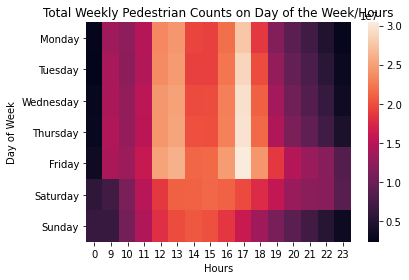

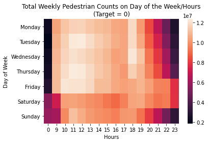

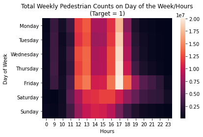

```python
hm1 = plt.figure(1)
hm1 = sns.heatmap(time_day)
hm1.set_xlabel('Hours')
hm1.set_ylabel('Day of Week')
hm1.set_title('Total Weekly Pedestrian Counts on Day of the Week/Hours')
plt.tight_layout()

hm2 = plt.figure(2)
hm2 = sns.heatmap(time_day0)
hm2.set_xlabel('Hours')
hm2.set_ylabel('Day of Week')
hm2.set_title('Total Weekly Pedestrian Counts on Day of the Week/Hours\n(Target = 0)')
plt.tight_layout()

hm3 = plt.figure(3)
hm3 = sns.heatmap(time_day1)
hm3.set_xlabel('Hours')
hm3.set_ylabel('Day of Week')
hm3.set_title('Total Weekly Pedestrian Counts on Day of the Week/Hours\n(Target = 1)')
plt.tight_layout()
```

The heatmaps above are based on the day of the week and the hours of the day. While the first heatmap reflects the same pattern as the line graph of Weekly Average & total Pedestrian Count, the pattern of pedestrian counts differs based on the target feature. The difference is especially significant during the weekends based on the target variable. Therefore, I added attribute `week` to differentiate weekend and weekdays for predicting the target.

## Adjusting Features and Target

```python
holiday = ['January-1','January-26',\
          'April-2','April-3','April-4','April-5','April-25',\
          'June-24',\
          'September-24',\
          'November-2',\
          'December-24','December-25','December-27','December-28',\
          'December-29','December-30','December-31']

warmerMonth = ['December', 'January', 'February', 'March', 'April']
weekends = ['Saturday', 'Sunday']
```

```python
sensor_avg = counts\
.select('Sensor_ID','Hourly_Counts')\
.groupBy('Sensor_ID')\
.mean('Hourly_Counts')\
.select(round(col('avg(Hourly_Counts)'),4).alias('sensor_avg'),\
       col('Sensor_ID').alias('id'))\
.orderBy('sensor_avg')
# joining the dataset with total and average pedestrian count of each sensor
# drop duplicate sensor and convert the dataset to pandas dataframe for visualisation
```

```python
sensor_avg_pd = sensor_avg.toPandas()
levels = pd.cut(sensor_avg_pd['sensor_avg'], bins = 6).unique().tolist()
# convert the pyspark dataframe to pandas dataframe
# create 6 different levels to categorise sensor ID
```

```python
l = [(levels[i].left+0.0001,levels[i].right) for i in range(len(levels))]
# different range of average pedestrian count for categorising sensor ID
```

```python
counts = counts.join(sensor_avg,\
           counts.Sensor_ID ==sensor_avg.id,\
           how = 'inner').drop('id')
```

```python
counts = counts\
.withColumn('holiday',when(concat(col('Month'),lit('-'),col('Mdate')).isin(holiday),1)\
           .otherwise(0))\
.withColumn('week', when(col('Day')=='Sunday', 1)\
           .when(col('Day') == 'Friday', 2)\
           .when(col('Day') == 'Saturday', 3)\
           .otherwise(4))\
.withColumn('hour', when(col('Time').isin([12,13]), 'lunch')\
           .when(col('Time').isin([*range(16,19)]), 'rushhour')\
           .otherwise('regular'))\
.withColumn('SensorCategory', when(col('sensor_avg').between(l[0][0], l[0][1]),0)\
                      .when(col('sensor_avg').between(l[1][0], l[1][1]),1)\
                      .when(col('sensor_avg').between(l[2][0], l[2][1]),2)\
                      .when(col('sensor_avg').between(l[3][0], l[3][1]),3)\
                      .when(col('sensor_avg').between(l[4][0], l[4][1]),4)\
                      .otherwise(5))\
.withColumn('warmerSeason', when(col('Month').isin(warmerMonth), 1)\
           .otherwise(0))
# 'holiday' attribute: first concatenate the 'Month' and 'Mdate' columns with'-'
# if the concatenated value is in 'holiday' list, the column is 'Y', otherwise 'N'
# 'hour' attribute: if 'Time' value is 12 or 13, then the level is 'lunch'
# if the value is 16, 17, or 18, the level is 'rushhour'
# otherwise is 'regular'
```

```python
filteredDataset = counts.select('SensorCategory','warmerSeason','week',\
                                'hour','holiday','above_threshold','Year')\
.filter(col('Time').isin([0,*range(9,23)]))\
.withColumnRenamed('above_threshold', 'label')
# prepare for the dataset with the features and label column
# unused columns and rows are filtered out for efficiency
```

```python
featureCols = ['SensorCategory','warmerSeason','week','hour','holiday']
# feature columns for transformation
```

## Preparing Spark ML Transformers/Estimators for features, labels, and models

```python
from pyspark.ml.linalg import Vectors
from pyspark.ml.classification import *
# classifiers, including decision trees, random forest, and gradient boost trees
from pyspark.ml.feature import *
# for ETL processing
from pyspark.ml import Pipeline
# pipelining the ETL + modelling process
```

```python
# 1. Transformers/Estmators
SI_input = featureCols
# features that needed to be converted into string indexers
SI_output = [f'{i}_index' for i in SI_input]
SI = StringIndexer(inputCols = SI_input,\
                  outputCols = SI_output)
```

```python
# 2. OneHotEncoder Transformations:
# transforming string indexers to binary vectors to prevent ordenality
OHE_input = SI.getOutputCols()
# the output columns from stringIndexers is the input column for OHE
OHE_output = [f'{i}_cat' for i in SI_input]
OHE = OneHotEncoder(inputCols = OHE_input,\
                   outputCols = OHE_output)
```

```python
# 3. VectorAssembler Transformation
# convert all the binary vectors and numerical features into a single sparce matrix
VA_input = OHE.getOutputCols()
VA_output = 'features'
VA = VectorAssembler(inputCols = VA_input,\
                    outputCol = VA_output)
```

```python
# DecisionTree classifier and Gradiant Boost Tree classifier
DT = DecisionTreeClassifier(featuresCol = 'features',\
                           labelCol = 'label')
GBT = GBTClassifier(featuresCol = 'features',\
                   labelCol = 'label')
```

```python
# pipeline the ETL-Modelling stages
pipe_DT = Pipeline(stages = [SI, OHE, VA, DT])
pipe_GBT = Pipeline(stages = [SI, OHE, VA, GBT])
```

## Preparing the training data and testing data

With the dataset at hand, I will use both gradient boost tree and decision tree classifiers to predict the pedestrian count in 2019 using the dateset from 2014 to 2018.

```python
# prepare for train and test datasets
train = filteredDataset.filter(col('Year').isin([*range(2014,2019)])).drop('Year')
test = filteredDataset.filter(col('Year') == 2019).drop('Year')
```

## Training the Model and Interpret the Important Features

```python
# fit the train dataset to the classifiers
pred_DT = pipe_DT.fit(train)
pred_GBT = pipe_GBT.fit(train)
```

```python
# retrieve the last stages of the pipeline for parameter examination
dtModel = pred_DT.stages[-1]
gbtModel = pred_GBT.stages[-1]
```

```python
# retrieving the 'most important features' for decision tree
# for this model, the 'importance' of a feature is evaluated through information gain
# the information gain from these models are obtained through Gini Index
pd.DataFrame(list(zip(VA.getInputCols(),dtModel.featureImportances)),\
                         columns = ['feature', 'importance'])\
.sort_values(by = ['importance'], ascending = False)\
.iloc[:3,:]
```

|  | feature | importance |
| --- | --- | --- |
| 1 | warmerSeason_cat | 0.348956 |
| 0 | SensorCategory_cat | 0.282511 |
| 2 | week_cat | 0.069051 |

```python
pd.DataFrame(list(zip(VA.getInputCols(),gbtModel.featureImportances)),\
                         columns = ['feature', 'importance'])\
.sort_values(by = ['importance'],ascending = False)\
.iloc[:3,:]
```

|  | feature | importance |
| --- | --- | --- |
| 0 | SensorCategory_cat | 0.368845 |
| 1 | warmerSeason_cat | 0.327412 |
| 2 | week_cat | 0.055439 |

Based on both classifiers, `SensorCategory` and `warmerSeason` features are the most important when predicting the hourly pedestrian counts in Melbourne. The higher the `importance`, the more information gain we obtain by splits.

```python
# predict the hourly pedestrian count with both classifiers
prediction_DT = pred_DT.transform(test)
prediction_GBT = pred_GBT.transform(test)
```

## Evaluating the Model

### 1. Confusion Metrics and FPR

```python
round = getattr(builtins, 'round')
'''
This function takes the predicted values and original label as the input parameter
and returns confusion metrics for evaluating classification models.
'''
def computeMetrics(prediction):

    FN = prediction.filter((col('prediction') == 0.0) & (col('label') == 1.0)).count()
    # false negatives
    FP = prediction.filter((col('prediction') == 1.0) & (col('label') == 0.0)).count()
    # false positives
    TP = prediction.filter((col('prediction') == 1.0) & (col('label') == 1.0)).count()
    # true positives
    TN = prediction.filter((col('prediction') == 0.0) & (col('label') == 0.0)).count()
    # true negatives

    accuracy = round((TP+TN)/(TP+TN+FP+FN),4)
    # the total number of correct predictions
    precision = round(TP/(TP+FP),4)
    # the proportion of true positive in respect to all the positives we classified
    recall = round(TP/(TP+FN),4)
    # the proportion of true positive in respect to all the positives & negatives we declared
    f1 = round((2*TP)/(2*TP+FP+FN),4)
    # balance of recall and precision
    FPR = round(FP/(FP+TN),4)

    return accuracy,precision,recall,f1, FPR
```

```python
predictions = [prediction_DT, prediction_GBT]

for p in predictions:

    confusionMatrix = computeMetrics(p)

    if p is prediction_DT: model = 'Decision Tree'
    else: model = 'Gradient Boost Model'

    print(model,f'\nAccuracy: {confusionMatrix[0]}\nPrecision: {confusionMatrix[1]}\nRecall: {confusionMatrix[2]}\nF1-Score: {confusionMatrix[3]}\nFPR: {confusionMatrix[4]}\n')
```

```
Decision Tree
Accuracy: 0.928
Precision: 0.7835
Recall: 0.4655
F1-Score: 0.584
FPR: 0.0157

Gradient Boost Model
Accuracy: 0.928
Precision: 0.7784
Recall: 0.4706
F1-Score: 0.5866
FPR: 0.0163
```

Due to severe class imbalance and the fact that majority of the class is 0 (False), we should evaluate the performance of the model with **precision** and **False Positive Rate**.

Depends on the purpose of this model, the model can be a two-sided sword: if the client is prone to look for the quiet time for pedestriant, for e.g. construction or traffic facilitation, the model could be an ideal choice. However, if the client is eager to catch the timeframe where pedestrian counts are high, the model is not recommended.

### 2. AUC-ROC Evaluation

```python
from pyspark.ml.evaluation import BinaryClassificationEvaluator
evaluator = BinaryClassificationEvaluator(rawPredictionCol="rawPrediction")
```

```python
auc_gbt = evaluator.evaluate(prediction_GBT)
auc_dt = evaluator.evaluate(prediction_DT)

print('DT')
print(auc_dt)
print(evaluator.getMetricName())

print('\nGBT')
print(auc_gbt)
print(evaluator.getMetricName())
```

```
DT
0.8881171709886897
areaUnderROC

GBT
0.9332793076781842
areaUnderROC
```

```python
from pyspark.mllib.evaluation import BinaryClassificationMetrics

class CurveMetrics(BinaryClassificationMetrics):
    def __init__(self, *args):
        super(CurveMetrics, self).__init__(*args)

    def _to_list(self, rdd):
        points = []
        # Note this collect could be inefficient for large datasets
        # considering there may be one probability per datapoint (at most)
        # The Scala version takes a numBins parameter,
        # but it doesn't seem possible to pass this from Python to Java
        for row in rdd.collect():
            # Results are returned as type scala.Tuple2,
            # which doesn't appear to have a py4j mapping
            points += [(float(row._1()), float(row._2()))]
        return points

    def get_curve(self, method):
        rdd = getattr(self._java_model, method)().toJavaRDD()
        return self._to_list(rdd)
```

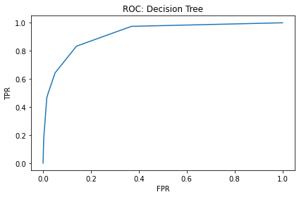

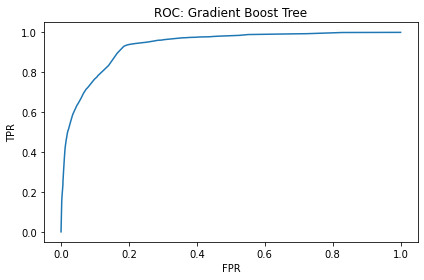

```python
preds = prediction_DT.select('label','probability').rdd.map(lambda row: (float(row['probability'][1]), float(row['label'])))
points = CurveMetrics(preds).get_curve('roc')
x_val = [x[0] for x in points]
y_val = [x[1] for x in points]

plt.figure(1)
plt.plot(x_val, y_val)
plt.xlabel('FPR')
plt.ylabel('TPR')
plt.title('ROC: Decision Tree')
plt.tight_layout()

preds = prediction_GBT.select('label','probability').rdd.map(lambda row: (float(row['probability'][1]), float(row['label'])))
points = CurveMetrics(preds).get_curve('roc')
x_val = [x[0] for x in points]
y_val = [x[1] for x in points]

plt.figure(2)
plt.plot(x_val, y_val)
plt.xlabel('FPR')
plt.ylabel('TPR')
plt.title('ROC: Gradient Boost Tree')
plt.tight_layout()
```

The ROC curve is a performance measurement for classification problems at various threshold settings. ROC is a probability curve and the area under the curve (AUC) is the degree/measure of separability, showing how much the model is capable of distinguishing between classes - the higher the AUC, the better the model is at accuracy.

The Gradient Boost Tree is performing significantly better at AUC metric in comparison to that of Decision Tree. However, due to severe imbalance of class, where 92% of the entry is 0, the AUC might not be an ideal choice for evaluating the performance of the models.

## Accessing the Parameters in the Model

```python
# Hyperparameters of Decision Tree
dtModel.extractParamMap()
```

```
{Param(parent='DecisionTreeClassifier_3faf26553d1a', name='featuresCol', doc='features column name.'): 'features',
 Param(parent='DecisionTreeClassifier_3faf26553d1a', name='labelCol', doc='label column name.'): 'label',
 Param(parent='DecisionTreeClassifier_3faf26553d1a', name='predictionCol', doc='prediction column name.'): 'prediction',
 Param(parent='DecisionTreeClassifier_3faf26553d1a', name='probabilityCol', doc='Column name for predicted class conditional probabilities. Note: Not all models output well-calibrated probability estimates! These probabilities should be treated as confidences, not precise probabilities.'): 'probabil…
 Param(parent='DecisionTreeClassifier_3faf26553d1a', name='rawPredictionCol', doc='raw prediction (a.k.a. confidence) column name.'): 'rawPrediction',
 Param(parent='DecisionTreeClassifier_3faf26553d1a', name='seed', doc='random seed.'): 7203051820479017227,
 Param(parent='DecisionTreeClassifier_3faf26553d1a', name='cacheNodeIds', doc='If false, the algorithm will pass trees to executors to match instances with nodes. If true, the algorithm will cache node IDs for each instance. Caching can speed up training of deeper trees. Users can set how often shou…
 Param(parent='DecisionTreeClassifier_3faf26553d1a', name='checkpointInterval', doc='set checkpoint interval (>= 1) or disable checkpoint (-1). E.g. 10 means that the cache will get checkpointed every 10 iterations. Note: this setting will be ignored if the checkpoint directory is not set in the Spa…
 Param(parent='DecisionTreeClassifier_3faf26553d1a', name='impurity', doc='Criterion used for information gain calculation (case-insensitive). Supported options: entropy, gini'): 'gini',
 Param(parent='DecisionTreeClassifier_3faf26553d1a', name='leafCol', doc='Leaf indices column name. Predicted leaf index of each instance in each tree by preorder.'): '',
 Param(parent='DecisionTreeClassifier_3faf26553d1a', name='maxBins', doc='Max number of bins for discretizing continuous features.  Must be >=2 and >= number of categories for any categorical feature.'): 32,
 Param(parent='DecisionTreeClassifier_3faf26553d1a', name='maxDepth', doc='Maximum depth of the tree. (>= 0) E.g., depth 0 means 1 leaf node; depth 1 means 1 internal node + 2 leaf nodes.'): 5,
 Param(parent='DecisionTreeClassifier_3faf26553d1a', name='maxMemoryInMB', doc='Maximum memory in MB allocated to histogram aggregation. If too small, then 1 node will be split per iteration, and its aggregates may exceed this size.'): 256,
 Param(parent='DecisionTreeClassifier_3faf26553d1a', name='minInfoGain', doc='Minimum information gain for a split to be considered at a tree node.'): 0.0,
 Param(parent='DecisionTreeClassifier_3faf26553d1a', name='minInstancesPerNode', doc='Minimum number of instances each child must have after split. If a split causes the left or right child to have fewer than minInstancesPerNode, the split will be discarded as invalid. Should be >= 1.'): 1,
 Param(parent='DecisionTreeClassifier_3faf26553d1a', name='minWeightFractionPerNode', doc='Minimum fraction of the weighted sample count that each child must have after split. If a split causes the fraction of the total weight in the left or right child to be less than minWeightFractionPerNode, the …
```

```python
# Hyperparameters of Gradient Boost Tree
gbtModel.extractParamMap()
```

```
{Param(parent='GBTClassifier_9740b1b81af0', name='featuresCol', doc='features column name.'): 'features',
 Param(parent='GBTClassifier_9740b1b81af0', name='labelCol', doc='label column name.'): 'label',
 Param(parent='GBTClassifier_9740b1b81af0', name='predictionCol', doc='prediction column name.'): 'prediction',
 Param(parent='GBTClassifier_9740b1b81af0', name='probabilityCol', doc='Column name for predicted class conditional probabilities. Note: Not all models output well-calibrated probability estimates! These probabilities should be treated as confidences, not precise probabilities.'): 'probability',
 Param(parent='GBTClassifier_9740b1b81af0', name='rawPredictionCol', doc='raw prediction (a.k.a. confidence) column name.'): 'rawPrediction',
 Param(parent='GBTClassifier_9740b1b81af0', name='seed', doc='random seed.'): -8615428386795093782,
 Param(parent='GBTClassifier_9740b1b81af0', name='cacheNodeIds', doc='If false, the algorithm will pass trees to executors to match instances with nodes. If true, the algorithm will cache node IDs for each instance. Caching can speed up training of deeper trees. Users can set how often should the ca…
 Param(parent='GBTClassifier_9740b1b81af0', name='checkpointInterval', doc='set checkpoint interval (>= 1) or disable checkpoint (-1). E.g. 10 means that the cache will get checkpointed every 10 iterations. Note: this setting will be ignored if the checkpoint directory is not set in the SparkContext…
 Param(parent='GBTClassifier_9740b1b81af0', name='featureSubsetStrategy', doc="The number of features to consider for splits at each tree node. Supported options: 'auto' (choose automatically for task: If numTrees == 1, set to 'all'. If numTrees > 1 (forest), set to 'sqrt' for classification and to …
 Param(parent='GBTClassifier_9740b1b81af0', name='impurity', doc='Criterion used for information gain calculation (case-insensitive). Supported options: variance'): 'variance',
 Param(parent='GBTClassifier_9740b1b81af0', name='leafCol', doc='Leaf indices column name. Predicted leaf index of each instance in each tree by preorder.'): '',
 Param(parent='GBTClassifier_9740b1b81af0', name='lossType', doc='Loss function which GBT tries to minimize (case-insensitive). Supported options: logistic'): 'logistic',
 Param(parent='GBTClassifier_9740b1b81af0', name='maxBins', doc='Max number of bins for discretizing continuous features.  Must be >=2 and >= number of categories for any categorical feature.'): 32,
 Param(parent='GBTClassifier_9740b1b81af0', name='maxDepth', doc='Maximum depth of the tree. (>= 0) E.g., depth 0 means 1 leaf node; depth 1 means 1 internal node + 2 leaf nodes.'): 5,
 Param(parent='GBTClassifier_9740b1b81af0', name='maxIter', doc='max number of iterations (>= 0).'): 20,
 Param(parent='GBTClassifier_9740b1b81af0', name='maxMemoryInMB', doc='Maximum memory in MB allocated to histogram aggregation. If too small, then 1 node will be split per iteration, and its aggregates may exceed this size.'): 256,
 Param(parent='GBTClassifier_9740b1b81af0', name='minInfoGain', doc='Minimum information gain for a split to be considered at a tree node.'): 0.0,
 Param(parent='GBTClassifier_9740b1b81af0', name='minInstancesPerNode', doc='Minimum number of instances each child must have after split. If a split causes the left or right child to have fewer than minInstancesPerNode, the split will be discarded as invalid. Should be >= 1.'): 1,
 Param(parent='GBTClassifier_9740b1b81af0', name='minWeightFractionPerNode', doc='Minimum fraction of the weighted sample count that each child must have after split. If a split causes the fraction of the total weight in the left or right child to be less than minWeightFractionPerNode, the split wil…
 Param(parent='GBTClassifier_9740b1b81af0', name='stepSize', doc='Step size (a.k.a. learning rate) in interval (0, 1] for shrinking the contribution of each estimator.'): 0.1,
 Param(parent='GBTClassifier_9740b1b81af0', name='subsamplingRate', doc='Fraction of the training data used for learning each decision tree, in range (0, 1].'): 1.0,
 Param(parent='GBTClassifier_9740b1b81af0', name='validationTol', doc='Threshold for stopping early when fit with validation is used. If the error rate on the validation input changes by less than the validationTol, then learning will stop early (before `maxIter`). This parameter is ignored when fit…
```

## Cross Validation and Hyperparameter Tuning

```python
from pyspark.ml.tuning import ParamGridBuilder, CrossValidator,CrossValidatorModel
```

```python
# Create ParamGrid for Cross Validation
dtparamGrid = (ParamGridBuilder()\
             .addGrid(DT.maxDepth, [*range(2,6)])\
             .build())

# 3-fold CrossValidator
dtcv = CrossValidator(estimator = pipe_DT,\
                      estimatorParamMaps = dtparamGrid,\
                      evaluator = evaluator,\
                      numFolds = 3)
```

```python
# Run cross validations
dtcvModel = dtcv.fit(train)
print(dtcvModel)
```

```
CrossValidatorModel_1d74ff477de4
```

```python
# choose the best model and inspect its hyperparameter
bestModel = dtcvModel.bestModel
print(bestModel.stages)
print('Best Parameters for Decision Tree: \n',\
     bestModel.stages[-1]._java_obj.paramMap())
```

```
[StringIndexerModel: uid=StringIndexer_ad4593249453, handleInvalid=error, numInputCols=5, numOutputCols=5, OneHotEncoderModel: uid=OneHotEncoder_b09789950957, dropLast=true, handleInvalid=error, numInputCols=5, numOutputCols=5, VectorAssembler_d4c300344e91, DecisionTreeClassificationModel: uid=Decis…
Best Parameters for Decision Tree:
 {
	DecisionTreeClassifier_3faf26553d1a-featuresCol: features,
	DecisionTreeClassifier_3faf26553d1a-labelCol: label,
	DecisionTreeClassifier_3faf26553d1a-maxDepth: 3
}
```

## Utilise the Best Model and Evaluate the Changes

```python
prediction_bestDT = dtcvModel.transform(test)
# use the test data to the new 'best model'
```

```python
confusionMatrix = computeMetrics(prediction_bestDT)
print(f'Fine-Tuned Decision Tree\nAccuracy: {confusionMatrix[0]}\nPrecision: {confusionMatrix[1]}\nRecall: {confusionMatrix[2]}\nF1-Score: {confusionMatrix[3]}\nFPR: {confusionMatrix[4]}\n')
```

```
Fine-Tuned Decision Tree
Accuracy: 0.9269
Precision: 0.7473
Recall: 0.4933
F1-Score: 0.5943
FPR: 0.0203
```

```python
pd.DataFrame(list(zip(VA.getInputCols(),bestModel.stages[-1].featureImportances)),\
                         columns = ['feature', 'importance'])\
.sort_values(by = ['importance'],ascending = False).iloc[:3,:]
```

|  | feature | importance |
| --- | --- | --- |
| 1 | warmerSeason_cat | 0.385315 |
| 0 | SensorCategory_cat | 0.311946 |
| 2 | week_cat | 0.000000 |

After fine-tuning the model and decreased its `maxDepth`, the depth of the decision tree decreased from 5 to 3 without major changes in the evaluation metrics. This means that the bias remained low, while the variance of the model also became lower than the former model.

## Saving the Model to the File System

```python
bestModel.save('pedestrianCountThreshold_PredictionModel')
```

# Bibliography

dataframe.describe() suppress scientific notation. (2016, October 31). Stack Overflow. https://stackoverflow.com/questions/40347689/dataframe-describe-suppress-scientific-notation

pyspark extract ROC curve? (2018, October 17). Stack Overflow. https://stackoverflow.com/questions/52847408/pyspark-extract-roc-curve